# R Workshop @TESRI

2019.03.05

## Introduction to R

## R & RStudio

[figure not shown]

### R language

- https://www.r-project.org/
- 免費開放原始碼軟體程式語言與操作環境
- Since 1993 (Ross Ihaka and Robert Gentleman)
- 目前由 R Core Team (約20位成員) 負責開發與維護
- 強項：統計分析、繪圖、資料探勘

[figure not shown]

### RStudio

- https://www.rstudio.com/
- 整合開發環境 (IDE, Integrated Development Environment)

## 安裝 R & RStudio

請參考「輕鬆學習 R 語言」  
http://www.learn-r-the-easy-way.tw/chapters/2#r

## Why programming?

以文字指令取代圖形化介面的拖拉點選操作流程

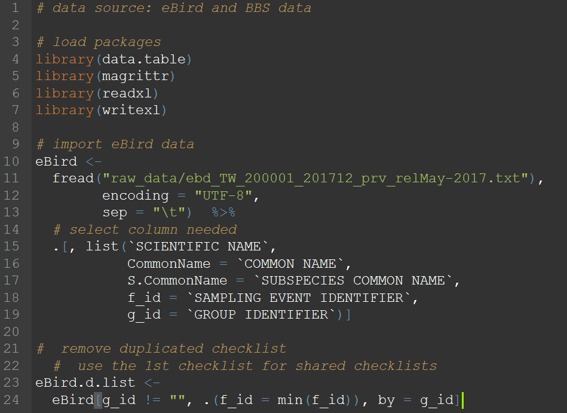

- 可重複執行性高，容易修改後再次執行
- 可以直接在指令中寫備註
- 操作流程容易分享給他人
- 執行重複性的任務 (迴圈)

## Why R?

### 1. 程式語言

- Reproducibility

### 2. 學界 (至少生態圈) 主流的資料分析語言

- 許多 paper 的分析方法都會附上 R code
- 相關 package 多 (`red`: IUCN red list index, `rtrim`: trim)

### 3. Open source

- 眾多現成的小工具 (packages)
- 教學網站、研討會、討論社群

## 預設的 RStudio 介面

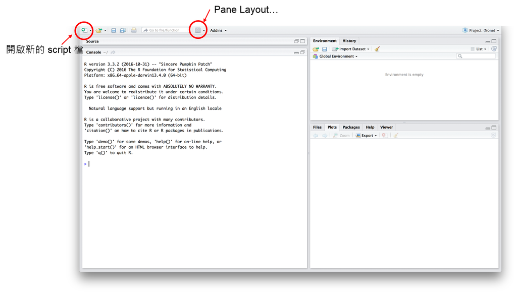

左上角  
**Workspace**  
寫程式碼的地方  
左下角  
**Console**  
執行程式碼的地方  
右上角  
**Environment**  
R 環境、歷史紀錄  
右下角  
**Files, Plot, Packages…**  
工作環境、輸出、套件

## 試著在 R 輸入一些東西吧

### 把 R 當計算機

```r
# 加(+)、減(-)、乘(*)、除(/)
1 + 1
3 * 5

# 次方(^)
2^10

# 取餘數(%%)
11 %% 3
```

- 程式碼可以寫在 Workspace，也可以寫在 Console
- 在 Workspace 執行程式按 `Ctrl Enter` (for windows), `Command Enter` (for Mac)
- 在 Console 執行程式按 `Enter`
- 建議將程式碼寫在 Workspace，比較好回溯做過什麼跟做筆記

## 儲存 Script

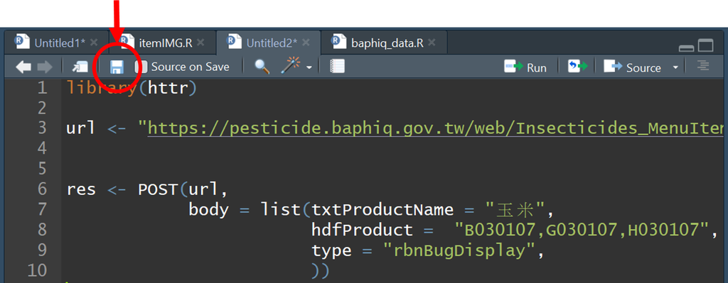

## Variable (變數) I

電腦裡面儲存資料要取檔案名稱，在 R 裡面暫存資料要取變數名稱  
用 `<-` 來指定資料到變數裡面

```r
# 把 123 儲存在 R 裡面，並且取名為 aaa
aaa <- 123
aaa = 123
```

接著在 Console 或 Workspace 執行 aaa，就可以看到裡面儲存的資訊

```
## [1] 123
```

再次指定資訊在相同名稱的變數的話，會直接把前一次的資訊覆蓋掉

```r
aaa <- 456; aaa
```

```
## [1] 456
```

## Variable (變數) II

變數可以直接拿來做運算

```r
# 指定 m 等於 3、n 等於 5
m <- 3
n <- 5
```

```r
# 計算 m + n
m + n
```

```
## [1] 8
```

沒有把結果指定進變數的話，執行完後會直接印出結果，但不會儲存在任何地方

## Variable (變數) III

命名的潛規則及注意事項

- 不要用中文。 Data <- 123 (O) 資料 <- 123 (X)
- 變數名稱開頭不要用數字。 Grid_1km (O) 1km_Grid (X)
- 變數名稱不能含有 空格 跟 /。 Date_01, Data-01 (O) Data 01 (X)
- 大小寫有差別， Data 不等於 data。
- 取有意義的名字。 RK.data (O) a, aa, aaa (X)
- 變數名稱不要取跟函數名稱相同。

## 變數格式

- Numeric (數值): `2`
- Logical (邏輯值): `TRUE, FALSE, T, F`
- Character (文字): `"這是文字"`
- Factor (類別)

```r
# 可用 class() 來查詢變數類型
class("這是文字")
```

```
## [1] "character"
```

```r
class(aaa)
```

```
## [1] "numeric"
```

## 變數結構

- Vector (向量)
- Matrix (矩陣)
- List (清單)
- Data.frame (資料表)

變數結構可用 `class()` 來查詢

## Vector (向量)

- 一維資料結構，R 語言中最基本的資料結構
- 只允許單一類型的資料內容

```r
# 產生一個 vector: c()，用 , 來分隔 vector 內的元素
V <- c("aa", "bb", 5)  # 產生 vector
V # 印出 V 的內容
```

```
## [1] "aa" "bb" "5"
```

```r
1:5  # 用 : 來建立連續整數的 vector，等同於 c(1, 2, 3, 4, 5)
```

```
## [1] 1 2 3 4 5
```

```r
# 選取部分 vector 的內容: [location]
V[2]
```

```
## [1] "bb"
```